# SpotifyR report

Author

Noor van Jaarsveld

# Let’s talk about Mimi Webb

## WHO IS SHE??

Mimi Webb is an English singer and songwriter, only 23 years old. She started here career during the pandemic, gaining more fame through TikTok.

## A quote she lives by

> ‘To be a star, you have to burn’

> **- Amelia Anne Webb**

## My favorite quote

> ‘I’m half brave, but scared of alone’

> **- Mimi Webb**

## Her Albums

- Seven Shades of Heartbreak (2021)
- Amelia (2023)

## My favorites

### Favorite album

[figure not shown]

### Favorite song

[Halfway (Official Music Video Youtube) - 22 October 2021](https://www.youtube.com/watch?v=sb-tVnrD5Wg)

[video not shown]

### Favorite lyrics

> And I’m thinkin’ ‘bout who I’ll be without you  
> In the middle of the bed we made  
> Now I’m walkin’ on the edge when I’m around you  
> How could love make you feel this way?

> *…*

## Data analysis

### Data source

I got my data by downloading the file of my artist, which was extracted using the *spotifyr* package, and then storing it in the data folder.

### Import data

```r
#packages needed for analysis
library(ggplot2)
library(dplyr)

#importing data into df
df <- read.csv("Mimi Webb.csv")
```

### Preview of the data frame

```r
df |> dplyr::slice_sample(n=5) |> knitr::kable(digits = 2)
```

| artist_name | track_name | track_number | album_name | album_release_year | album_release_date | valence | energy | danceability | loudness | tempo | speechiness | instrumentalness | liveness | key_name | mode_name | key_mode | duration_ms |
| --- | --- | --- | --- | --- | --- | --- | --- | --- | --- | --- | --- | --- | --- | --- | --- | --- | --- |
| Mimi Webb | See You Soon | 11 | Amelia | 2023 | 2023-04-28 | 0.62 | 0.66 | 0.66 | -3.88 | 91.98 | 0.03 | 0 | 0.12 | F# | minor | F# minor | 158601 |
| Mimi Webb | House On Fire | 4 | Amelia | 2023 | 2023-04-28 | 0.46 | 0.75 | 0.59 | -4.49 | 75.21 | 0.16 | 0 | 0.24 | D | major | D major | 139001 |
| Mimi Webb | Little Bit Louder | 3 | Seven Shades of Heartbreak | 2021 | 2021-10-22 | 0.59 | 0.73 | 0.72 | -5.21 | 116.05 | 0.05 | 0 | 0.14 | D | major | D major | 155757 |
| Mimi Webb | Last Train To London (I Won’t Look Back) | 13 | Amelia | 2023 | 2023-04-28 | 0.28 | 0.32 | 0.52 | -6.92 | 72.86 | 0.03 | 0 | 0.08 | A | major | A major | 232606 |
| Mimi Webb | Dumb Love | 1 | Seven Shades of Heartbreak | 2021 | 2021-10-22 | 0.17 | 0.42 | 0.57 | -5.86 | 76.96 | 0.03 | 0 | 0.06 | C | major | C major | 206161 |

### Data preparation

```r
# Remove records with the same track names
df <- df |> distinct(track_name, .keep_all = TRUE)
# Filter out track names that include "Live at" or "Live Acoustic"
df <- df |> filter(!grepl("Live at|Live Acoustic", track_name))
# Change the data type of album_name from numeric into character
df$album_name <- as.character(df$album_name)
```

### Album analysis

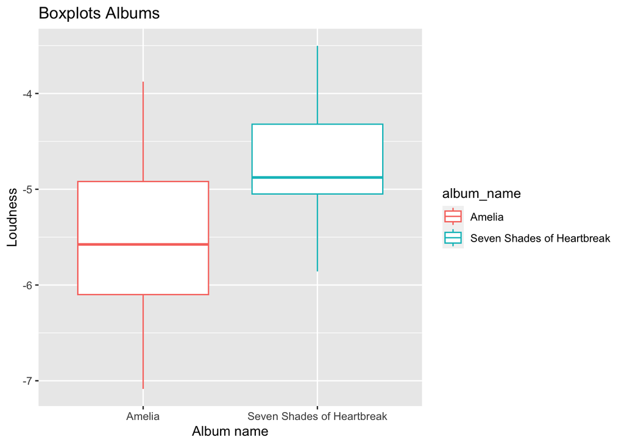

```r
# Change album_name from character to factor before starting the plot
df$album_name <- as.factor(df$album_name)
# Boxplot
ggplot(df, aes(x=album_name, y=loudness, color=album_name))+
  geom_boxplot()+
  labs(title= "Boxplots Albums", x="Album name", y="Loudness")
```

*Seven Shades of Heartbreak* is louder than *Amelia*!

### Valence and Loudness of her songs

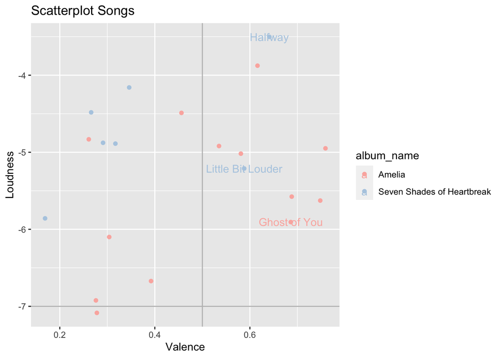

```r
# Labeling songs
subgroup <- df |> filter(track_name %in% c("Halfway", "Ghost of You", "Little Bit Louder"))
# Scatterplot
p <- ggplot(df, aes(x=valence, y=loudness, color=album_name))+
      geom_point()+
      geom_hline(yintercept=-7, color="grey")+
      geom_vline(xintercept=0.5, color="grey")+
      geom_text(data=subgroup, aes(label=track_name))+
      labs(title= "Scatterplot Songs", x="Valence", y="Loudness")

p + scale_color_brewer(palette = "Pastel1")
```

### Mimi’s most danceable songs:

```r
# Danceable
df |> slice_max(danceability, n=3) |> dplyr::select(track_name, album_name, album_release_year, danceability) |> knitr::kable(digits = 2)
```

| track_name | album_name | album_release_year | danceability |
| --- | --- | --- | --- |
| Red Flags | Amelia | 2023 | 0.84 |
| Ghost of You | Amelia | 2023 | 0.72 |
| Remind You | Amelia | 2023 | 0.72 |

Amelia seems to be a more danceable album!

### Mimi’s most energetic songs

```r
# Energetic
df |> slice_max(energy, n=3) |> dplyr::select(track_name, album_name, album_release_year, energy) |> knitr::kable(digits = 2)
```

| track_name | album_name | album_release_year | energy |
| --- | --- | --- | --- |
| Freezing | Amelia | 2023 | 0.89 |
| Halfway | Seven Shades of Heartbreak | 2021 | 0.84 |
| Remind You | Amelia | 2023 | 0.83 |

As you can see danceablity does not necessarily mean energy

### Mimi’s most positive songs

```r
# Positive
df |> slice_max(valence, n=3) |> dplyr::select(track_name, album_name, album_release_year, valence) |> knitr::kable(digits = 2)
```

| track_name | album_name | album_release_year | valence |
| --- | --- | --- | --- |
| Freezing | Amelia | 2023 | 0.76 |
| Red Flags | Amelia | 2023 | 0.75 |
| Amelia | Amelia | 2023 | 0.69 |

Freezing is both the most energetic and most positive song by Mimi! LETS VIBE!

[Freezing (Official Music Video Youtube) - 3 March 2023](https://www.youtube.com/watch?v=tClJ98w3Y5A)

[video not shown]

Red Flags is the most danceable and positve! LETS DANCE!

[Red Flags (Official Music Video Youtube) - 13 January 2023](https://www.youtube.com/watch?v=5xvRopbTEXw)

[video not shown]

### Tempo and density albums

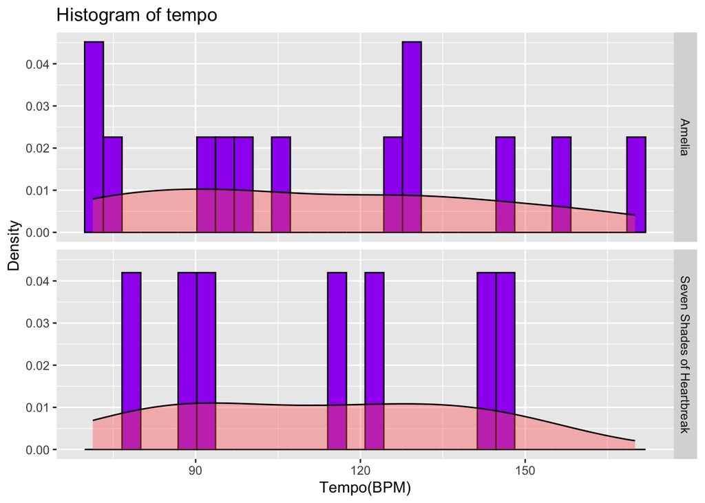

```r
# Histogram
ggplot(df, aes(x=tempo))+
  geom_histogram(aes(y=..density..), color="black", fill="purple")+
  geom_density(alpha=0.4, fill="#FF6666")+
  facet_grid(album_name~.)+
  labs(title="Histogram of tempo", x="Tempo(BPM)", y="Density")
```

### Speechiness in relation to valence

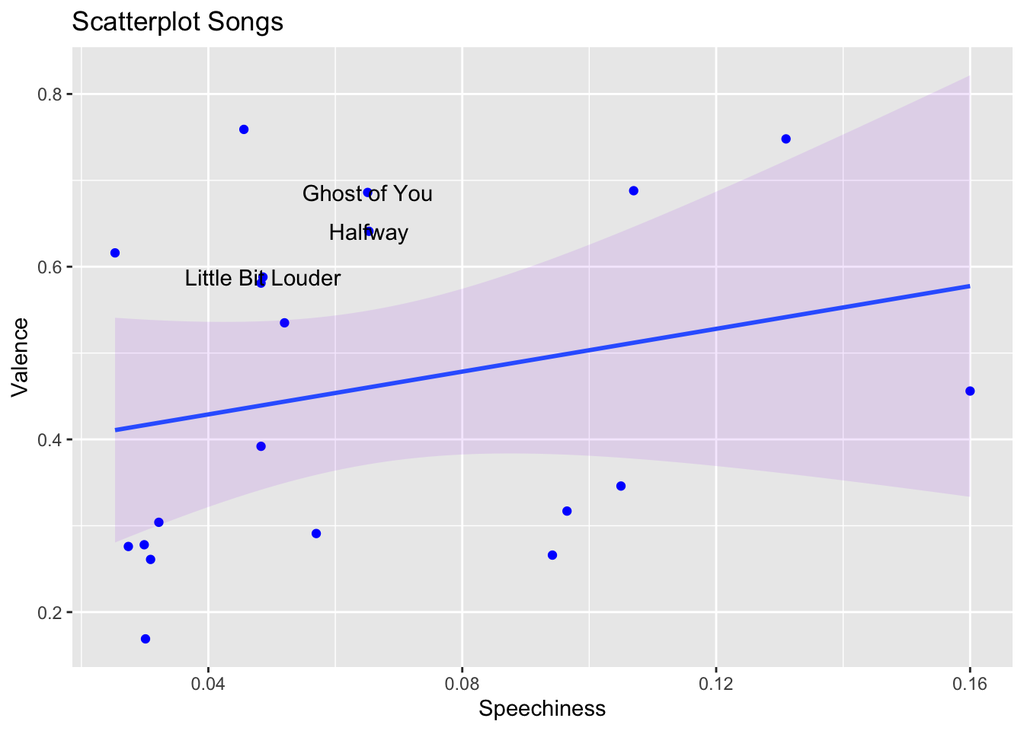

```r
# Labeling songs
subgroup <- df |> filter(track_name %in% c("Halfway", "Ghost of You", "Little Bit Louder"))

# Scatter plot with trend
ggplot(df, aes(x=speechiness, y=valence))+
  geom_point(color="blue")+
  geom_smooth(method="lm", alpha=0.1, fill="purple")+
  geom_text(data=subgroup, aes(label=track_name))+
  labs(title= "Scatterplot Songs", x="Speechiness", y="Valence")
```

Even though it is a weak increase, the higher the speechiness of Mimi’s songs, the more positive!

## GO LISTEN TO MIMI WEBB!!!!!